# Coursera Capstone Milestone Report

Sunday, July 26, 2015

# Overview

The Coursera Capstone Project leverages natural language processing to predict next word completions of a given phrase by using the HC Corpora (www.corpora.heliohost.org) data. This report outlines the exploratory data analysis of the corpus. With the completion of the initial analysis, the predictive model will be generated.

# Data Files

The HC Corpora consists of three sets of data files for four languages. Each set consists of blog, news and twitter raw data. This analysis focuses on the US-English language set which has the following profile (raw file data):

| Filename | Line Count | Word Count | File Size (B) |
| --- | --- | --- | --- |
| en_US.blogs.txt | 899,288 | 37,334,114 | 210,160,014 |
| en_US.news.txt | 1,010,242 | 34,365,936 | 205,811,889 |
| en_US.twitter.txt | 2,360,148 | 30,359,852 | 167,105,338 |

# Analysis

A corpus was created using a sampling of the three data files and the corpus was cleansed using the following transformations:

- Convert all words to lower cases
- Remove numbers
- Remove punctuations
- Remove special characters
- Remove standard English stop words
- Remove basic profanity
- Remove white space
- Stemmed the document

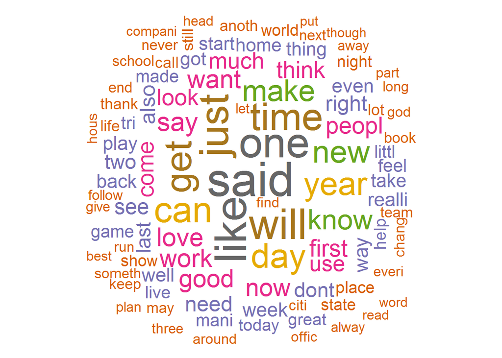

```
## <<TermDocumentMatrix (terms: 2337, documents: 3)>>
## Non-/sparse entries: 3029/3982
## Sparsity           : 57%
## Maximal term length: 21
## Weighting          : term frequency (tf)
```

In addition, the following is a histogram of the top 5 most frequent words for the corpus:

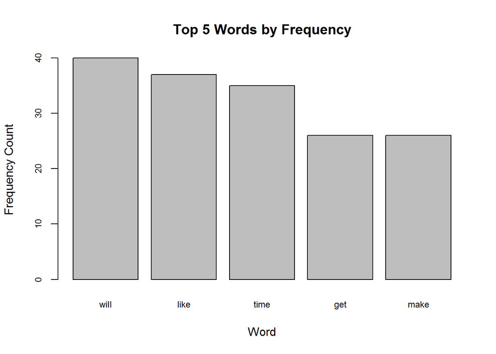

Top 5 frequent words for content:

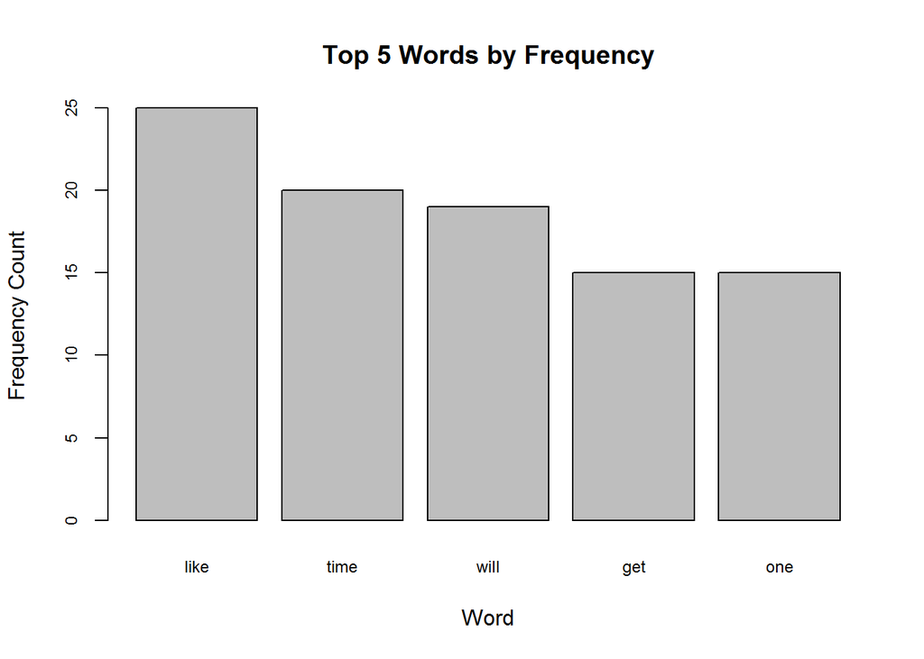

Top 5 frequent words for meta :

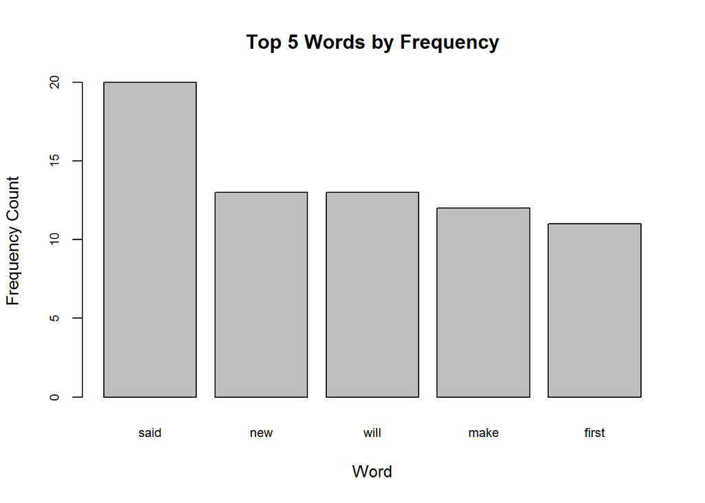

Top 5 frequent words for dmeta:

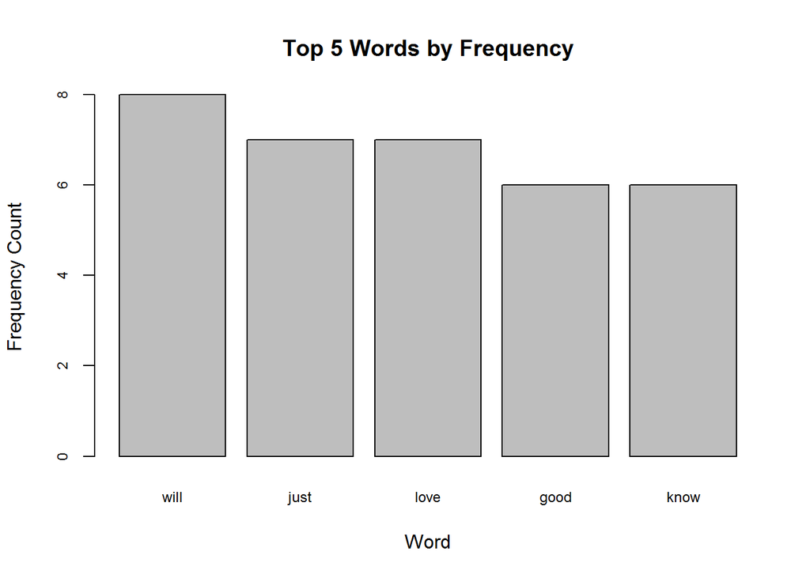

# Modeling Approach

The next step will include generation of the predictive model. The approach will consist of creating a training data set from the corpus and creating a 2, 3 and 4 n-gram hierachy. Then backtracking will be used to match the input text against the n-gram starting with the most restrictive 4 n-gram and then backtracking to 2 n-gram if a match is not found.